# Programming Analytical Methods - project

### **Introduction**

The aim of this study is to find the appropriate distribution to the data on poviat budget income per capita in 2020. For this purpose, the maximum likelihood method, the method of moments and the generalized method of moments were used. Then the obtained distributions were verified. The data comes from the main Statistical Office.

### **Data**

```r
library("maxLik")
library(tseries)

data = read.csv('data.csv', sep = ';', header = 1)

x = data$Income
logx = log(x)
n = length(x)

summary(x)
```

```
##    Min. 1st Qu.  Median    Mean 3rd Qu.    Max.
##     744    1242    1385    1405    1553    2357
```

### **Preliminary graphical data analysis**

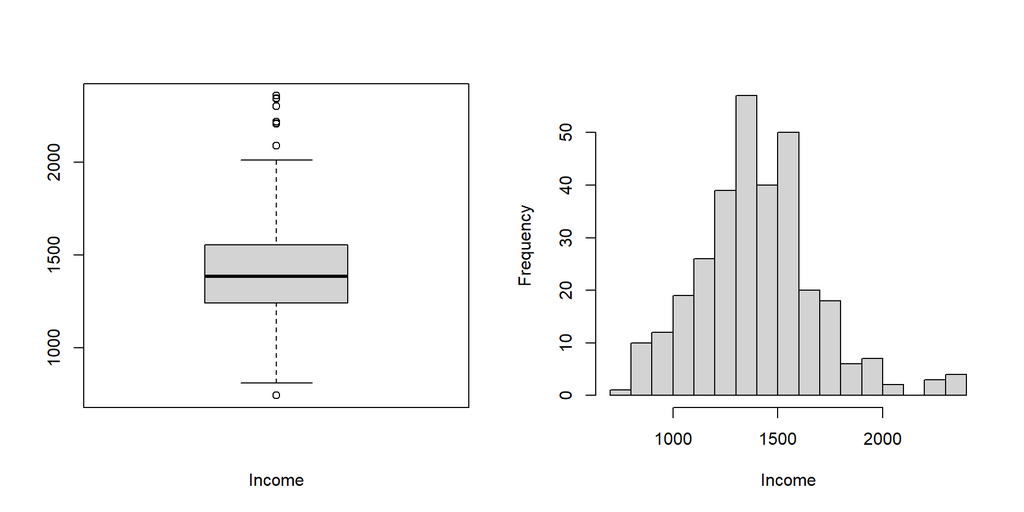

```r
par(mfrow=c(1,2))
boxplot(x, xlab = "Income")
hist(x, main = NULL, xlab = "Income", breaks = 12)
```

```r
jarque.bera.test(x)
```

```
##
##  Jarque Bera Test
##
## data:  x
## X-squared = 27.634, df = 2, p-value = 9.984e-07
```

Graphical analysis suggests that the distribution is close to a normal distribution, but there are many outliers pointing in one direction. The Jarque-Bera test also suggests rejecting the normal distribution hypothesis. It can be assumed that taking the logarithm of the data will bring them to a normal distribution.

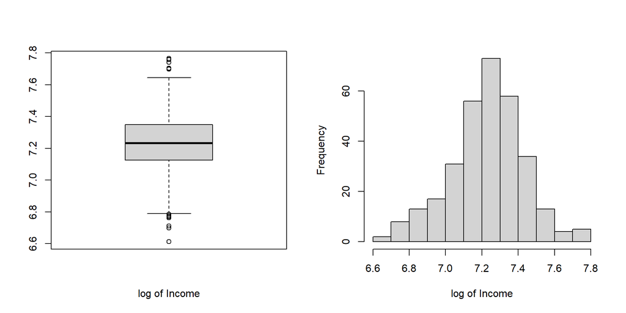

```r
par(mfrow=c(1,2))
boxplot(logx, xlab = "log of Income")
hist(logx, main = NULL, xlab = "log of Income", breaks = 12)
```

```r
jarque.bera.test(logx)
```

```
##
##  Jarque Bera Test
##
## data:  logx
## X-squared = 3.7415, df = 2, p-value = 0.154
```

The logarithm of the data made the observations evenly distributed. The Jarque-Bera test confirms that this variable is normally distributed. If Y = logX is normally distributed with the parameters µ, σ, this means that the variable X will be log-normally distributed with the same parameters. Therefore, in the next steps, the parameters for logX were estimated using a normal distribution, and then it was verified whether X is log-normally distributed with these parameters.

### **Parameters estimation**

### Maximum likelihood estimation

**likelihood function**

```r
L = function(param){
  miu = param[1]
  sigma = param[2]
  return( ((1/(sigma*sqrt(2*pi)))^n) * exp( (-1/(2*sigma^2))*sum((logx - miu)^2) ) )
}
```

**logarithm of the likelihood function**

```r
logL = function(param){
  miu = param[1]
  sigma = param[2]
  return(-1/2*n*log(2*pi) - n*log(sigma) - (1/2)*sum((logx - miu)^2/sigma^2))
}
```

**gradient**

```r
gradlogL = function(param){
  miu = param[1]
  sigma = param[2]
  grad = numeric(2)
  grad[1] = sum( (logx-miu)/sigma^2 )
  grad[2] = -n/sigma + sum( (logx-miu)^2/sigma^3 )
  return(grad)
}
```

**hessian**

```r
heslogL = function(param){
  miu = param[1]
  sigma = param[2]
  hessian = matrix(0, nrow = 2, ncol = 2)
  hessian[1,1] = n/sigma^3 - 3*sum((logx-miu)^2/sigma^4)
  hessian[1,2] = -2*sum( (logx-miu)/sigma^3 )
  hessian[2,1] = hessian[1,2]
  hessian[2,2] = -n/sigma^2
  return(hessian)
}
```

**Results**

```r
res = maxNR(fn = logL, grad = gradlogL, hess = heslogL, start = c(mean(logx),sd(logx)))

res$estimate
```

```
## [1] 7.2273830 0.2022326
```

**Kolmogorov–Smirnov test**

```r
mi = 7.2273830
sigma = 0.2022326
ks.test(x, 'plnorm', mi, sigma)
```

```
##
##  Asymptotic one-sample Kolmogorov-Smirnov test
##
## data:  x
## D = 0.061018, p-value = 0.1928
## alternative hypothesis: two-sided
```

There is no reason to reject the hypothesis of the equality of probability distributions.The distribution is log-normal with the parameters obtained in the estimation process.

### Comparison of distribution functions

A graphical comparison of the empirical distribution function with the distribution function of a log-normal distribution with parameters µ, σ obtained using the maximum likelihood method also shows that the data represent this distribution

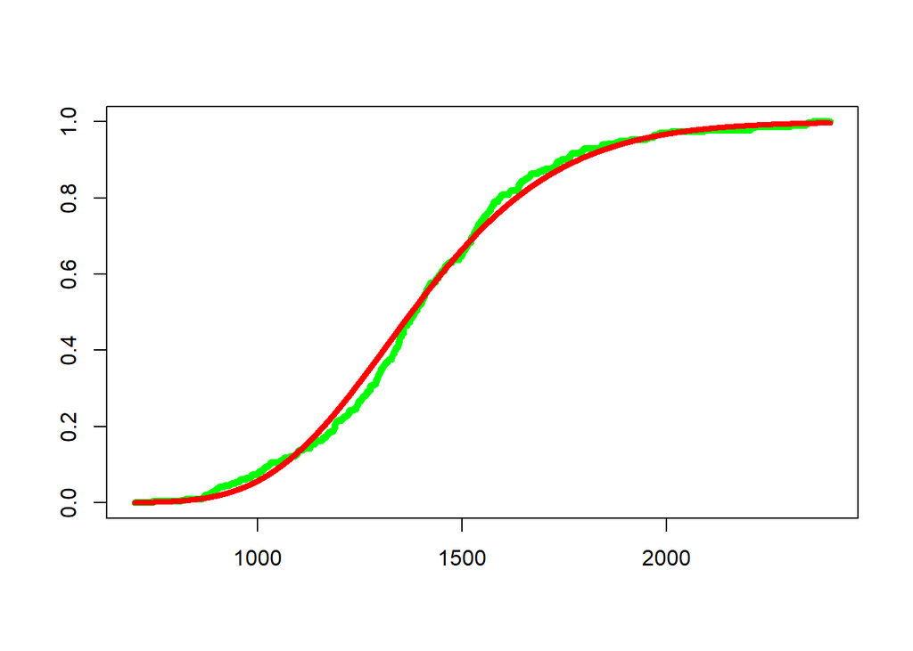

```r
empirical = ecdf(x)
xx = seq(700,2400, by= 0.5)
plot(xx, empirical(xx), type = 'l', col = 'green', lwd=5, xlab = "", ylab = "")
lines(xx, plnorm(xx, mi,sigma), col= "red", lwd=4)
```

### Quantile-quantile (q-q) plot

The quantile plot compares the empirical quantiles with the theoretical quantiles. It is very close to the 45-degree line, which also proves the high similarity of the distributions

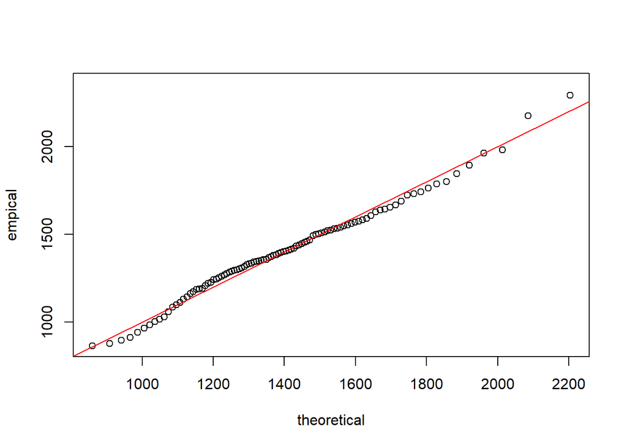

```r
q_empical = quantile(x, prob = 1:100/100)
q_theoretical = qlnorm(1:100/100, mean = mi, sd = sigma)
plot(q_theoretical, q_empical, ylab = "empical", xlab = "theoretical")
abline(0,1, col = "red")
```

### Alternative estimation methods: method of moments and generalized method of moments

**Method of moments**

```r
sd(logx)
```

```
## [1] 0.2024512
```

```r
mean(logx)
```

```
## [1] 7.227384
```

Very close results

**Generalized method of moments**

```r
f <- function(param){
  mi = param[1]
  sigma = param[2]
  m = rbind(logx-mi, (logx-mi)^2-sigma^2, (logx-mi)^4-3*sigma^4)
  M = rowMeans(m)
  W = m%*%t(m)/n

  return(-t(M)%*%solve(W)%*%M)
}

res_gmm = maxNR(f, start = c(mean(logx),sd(logx)))
summary(res_gmm)
```

```
## --------------------------------------------
## Newton-Raphson maximisation
## Number of iterations: 3
## Return code: 1
## gradient close to zero (gradtol)
## Function value: -0.0100754
## Estimates:
##       estimate      gradient
## [1,] 7.2224823  2.766849e-07
## [2,] 0.2065855 -7.476294e-07
## --------------------------------------------
```

Again very similar results